# Comparing Many Means with ANOVA

## Goal of an ANOVA

Analysis of variance (ANOVA) compares the means of three of more groups to detect if the means of the groups are different.

- ANOVA assess the differences in the group means relative to the variability in the observations within each group.

Ideally, we’d like to see:

- large differences in the means of the groups
- small amounts of variability within each group

## Visualizing Differences

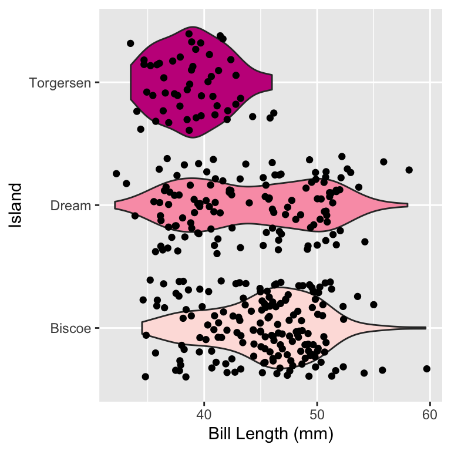

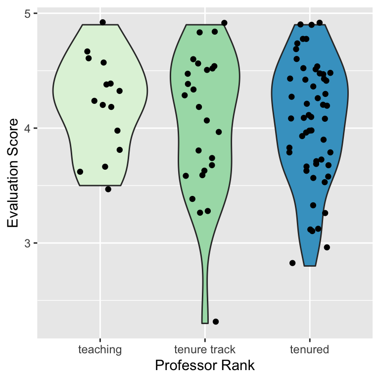

What can you say about the differences between the groups?

What can you say about the variability within the groups?

## Hypotheses

ANOVA uses a single hypothesis test to assess whether the means across many groups are equal.

- What would be the null hypothesis for the `evals` dataset?
  - What is the population parameter associated with the null hypothesis?
- What would be the alternative hypothesis for the `evals` dataset?

## Model Conditions for ANOVA

Before performing an ANOVA, there are three conditions we must check:

- the observations are independent *within* and *across* groups
- the data within each group should be nearly normal
- the variability across the groups should be similar

What decisions would you reach for the conditions of the `penguins` and `evals` datasets?

## Sum of Squares

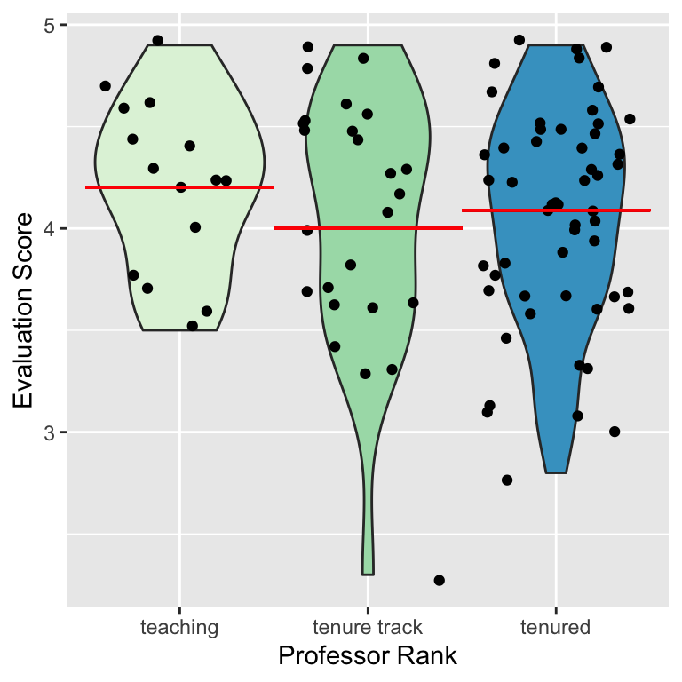

- What do the red lines represent?
  - How are those used in the sum of squares calculation?
- What do the points represent?
  - How are those used in the sum of squares calculation?

## Decomposing an ANOVA Table

```
## # A tibble: 2 x 6
##   term         df  sumsq meansq statistic p.value
##   <chr>     <dbl>  <dbl>  <dbl>     <dbl>   <dbl>
## 1 rank          2   1.59  0.795      2.71  0.0679
## 2 Residuals   460 135.    0.294     NA    NA
```

- What do the two *rows* correspond to?
- What is the difference between `sumsq` and `meansq`?
- How is the `statistic` calculated?
- How is the `p.value` calculated?

## Randomization Test for ANOVA

If the null hypothesis is true, then the evaluation score of each professor should represent their true teaching ability.

- How would you create a simulated null distribution to test for a difference in evaluation scores between the different ranks of professors?
- How is this process the same or different from a simulating a null distribution for a difference in means?

## Visualizing the Null Distribution

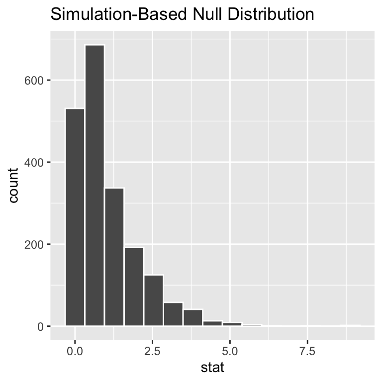

- Why are there no negative values on the distribution?
- Why is the peak of the distribution at 1?
- How would you calculate the p-value for the hypothesis test based on this distribution?

## Making a Conclusion

```
## # A tibble: 1 x 1
##   p_value
##     <dbl>
## 1   0.606
```

Based on the p-value above, what conclusion would you reach for this hypothesis test?

Why do you suspect that the p-value using an \(F\)-distribution is much lower (0.0679)?

## Comparing with a Parametric Test

- How would the process we just carried out differ, if we chose to use an \(F\)-distribution instead of simulating the null distribution?
- What are benefits of using an \(F\)-distribution?
- What are the costs of using an \(F\)-distribution?

## Code Used in Collaboration

All of the slides after this slide are for the `R` code that was used during this presentation!

## Penguin Visualizations

```r
penguins %>%
  ggplot(aes(x = bill_length_mm, y = island)) +
  geom_violin(aes(fill = island)) +
  geom_jitter() +
  theme(legend.position = "none") +
  scale_fill_brewer(palette = "RdPu")
```

## Evals Visualization

```r
evals %>%
  ggplot(aes(x = rank, y = score)) +
  geom_violin(aes(fill = rank)) +
  geom_jitter() +
  theme(legend.position = "none") +
  scale_fill_brewer(palette = "GnBu")
```

## Sum of Squares

```r
means <- evals_small %>%
  group_by(rank) %>%
  summarise(mean_score = mean(score))

evals_small %>%
  ggplot(aes(x = rank, y = score)) +
  geom_violin(aes(fill = rank)) +
  geom_jitter() +
  theme(legend.position = "none") +
  scale_fill_brewer(palette = "GnBu") +
  labs(x = "Professor Rank",
       y = "Evaluation Score") +
  geom_segment(x = 0.5, y = 4.2, xend = 1.5, yend = 4.2, color = "red") +
  geom_segment(x = 1.5, y = 4, xend = 2.5, yend = 4, color = "red") +
  geom_segment(x = 2.5, y = 4.09, xend = 3.5, yend = 4.09, color = "red")
```

## ANOVA Table

```r
aov(score ~ rank, data = evals) %>%
  tidy()
```

## Null Distribution

```r
null_dist <- evals_small %>%
  specify(score ~ rank) %>%
  hypothesise(null = "independence") %>%
  generate(reps = 2000, type = "permute") %>%
  calculate(stat = "F")

obs_F <- evals_small %>%
  specify(score ~ rank) %>%
  calculate(stat = "F")

null_dist %>%
  visualise() +
  shade_p_value(obs_stat = obs_F, direction = "greater")
```

## p-value Calculation

```r
null_dist %>%
  get_p_value(obs_stat = obs_F, direction = "greater")
```